# Homework 6

Araks Karapetyan

04.12.2018

(2 points) Read the file groceries which contains data about transactions made in the market Make the data usable for Association Rules Mining. (Hint. You can use function read.transactions) plot the data to see what are the first 5 most frequent items

```r
library(arules)
```

```r
library(arulesViz)
groceries <- read.transactions("groceries.csv",  sep=",")
inspect(groceries[1:10])
```

```
##      items
## [1]  {citrus fruit,
##       margarine,
##       ready soups,
##       semi-finished bread}
## [2]  {coffee,
##       tropical fruit,
##       yogurt}
## [3]  {whole milk}
## [4]  {cream cheese,
##       meat spreads,
##       pip fruit,
##       yogurt}
## [5]  {condensed milk,
##       long life bakery product,
##       other vegetables,
##       whole milk}
## [6]  {abrasive cleaner,
##       butter,
##       rice,
##       whole milk,
##       yogurt}
## [7]  {rolls/buns}
## [8]  {bottled beer,
##       liquor (appetizer),
##       other vegetables,
##       rolls/buns,
##       UHT-milk}
## [9]  {potted plants}
## [10] {cereals,
##       whole milk}
```

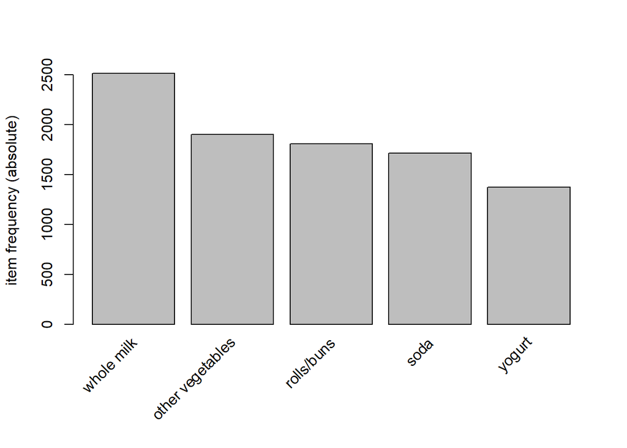

```r
itemFrequencyPlot(groceries, topN=5, type="absolute")
```

(5 points) Using appriori algorithm, create the rules by setting the support to be 0.005 and confidence to be 0.1 Set the length of the rules to be 4. Interpret the meaning of support and confidence.

```r
rules <- apriori(groceries, parameter = list(minlen = 4, maxlen = 4, supp = 0.005, conf = 0.1))
```

```
## Apriori
##
## Parameter specification:
##  confidence minval smax arem  aval originalSupport maxtime support minlen
##         0.1    0.1    1 none FALSE            TRUE       5   0.005      4
##  maxlen target   ext
##       4  rules FALSE
##
## Algorithmic control:
##  filter tree heap memopt load sort verbose
##     0.1 TRUE TRUE  FALSE TRUE    2    TRUE
##
## Absolute minimum support count: 49
##
## set item appearances ...[0 item(s)] done [0.00s].
## set transactions ...[169 item(s), 9835 transaction(s)] done [0.02s].
## sorting and recoding items ... [120 item(s)] done [0.00s].
## creating transaction tree ... done [0.01s].
## checking subsets of size 1 2 3 4
```

```
##  done [0.01s].
## writing ... [48 rule(s)] done [0.00s].
## creating S4 object  ... done [0.00s].
```

```r
inspect(rules[1:5])
```

```
##     lhs                        rhs                         support confidence     lift count
## [1] {fruit/vegetable juice,
##      other vegetables,
##      yogurt}                => {whole milk}            0.005083884  0.6172840 2.415833    50
## [2] {fruit/vegetable juice,
##      whole milk,
##      yogurt}                => {other vegetables}      0.005083884  0.5376344 2.778578    50
## [3] {fruit/vegetable juice,
##      other vegetables,
##      whole milk}            => {yogurt}                0.005083884  0.4854369 3.479790    50
## [4] {other vegetables,
##      whole milk,
##      yogurt}                => {fruit/vegetable juice} 0.005083884  0.2283105 3.158135    50
## [5] {other vegetables,
##      root vegetables,
##      whipped/sour cream}    => {whole milk}            0.005185562  0.6071429 2.376144    51
```

```r
#In case of the first row support shows the probability that fruit/vegetable juice, other vegetables, yogurt and whole milk will be bought together.
#In case of the first row confidence shows the probability of milk being in the transaction if fruit/vegetable juice, other vegetables, yogurt were there.
```

(7 points) Inspect the first 5 rules. Sort them by support in descending order. Interpret the first 2 rules. What is the meaning of support, confidence and lift?

```r
inspect(rules[1:5])
```

```
##     lhs                        rhs                         support confidence     lift count
## [1] {fruit/vegetable juice,
##      other vegetables,
##      yogurt}                => {whole milk}            0.005083884  0.6172840 2.415833    50
## [2] {fruit/vegetable juice,
##      whole milk,
##      yogurt}                => {other vegetables}      0.005083884  0.5376344 2.778578    50
## [3] {fruit/vegetable juice,
##      other vegetables,
##      whole milk}            => {yogurt}                0.005083884  0.4854369 3.479790    50
## [4] {other vegetables,
##      whole milk,
##      yogurt}                => {fruit/vegetable juice} 0.005083884  0.2283105 3.158135    50
## [5] {other vegetables,
##      root vegetables,
##      whipped/sour cream}    => {whole milk}            0.005185562  0.6071429 2.376144    51
```

```r
rules_supp <- sort(rules, by = "support")
inspect(rules_supp)
```

```
##      lhs                        rhs                         support confidence     lift count
## [1]  {other vegetables,
##       root vegetables,
##       yogurt}                => {whole milk}            0.007829181  0.6062992 2.372842    77
## [2]  {root vegetables,
##       whole milk,
##       yogurt}                => {other vegetables}      0.007829181  0.5384615 2.782853    77
## [3]  {other vegetables,
##       root vegetables,
##       whole milk}            => {yogurt}                0.007829181  0.3377193 2.420896    77
## [4]  {other vegetables,
##       whole milk,
##       yogurt}                => {root vegetables}       0.007829181  0.3515982 3.225716    77
## [5]  {other vegetables,
##       tropical fruit,
##       yogurt}                => {whole milk}            0.007625826  0.6198347 2.425816    75
## [6]  {tropical fruit,
##       whole milk,
##       yogurt}                => {other vegetables}      0.007625826  0.5033557 2.601421    75
## [7]  {other vegetables,
##       tropical fruit,
##       whole milk}            => {yogurt}                0.007625826  0.4464286 3.200164    75
## [8]  {other vegetables,
##       whole milk,
##       yogurt}                => {tropical fruit}        0.007625826  0.3424658 3.263712    75
## [9]  {other vegetables,
##       root vegetables,
##       tropical fruit}        => {whole milk}            0.007015760  0.5702479 2.231750    69
## [10] {root vegetables,
##       tropical fruit,
##       whole milk}            => {other vegetables}      0.007015760  0.5847458 3.022057    69
## [11] {other vegetables,
##       tropical fruit,
##       whole milk}            => {root vegetables}       0.007015760  0.4107143 3.768074    69
## [12] {other vegetables,
##       root vegetables,
##       whole milk}            => {tropical fruit}        0.007015760  0.3026316 2.884091    69
## [13] {other vegetables,
##       rolls/buns,
##       root vegetables}       => {whole milk}            0.006202339  0.5083333 1.989438    61
```

[output cut: 90 more lines]

```
## [44] {other vegetables,
##       whole milk,
##       yogurt}                => {fruit/vegetable juice} 0.005083884  0.2283105 3.158135    50
## [45] {other vegetables,
##       pip fruit,
##       yogurt}                => {whole milk}            0.005083884  0.6250000 2.446031    50
## [46] {pip fruit,
##       whole milk,
##       yogurt}                => {other vegetables}      0.005083884  0.5319149 2.749019    50
## [47] {other vegetables,
##       pip fruit,
##       whole milk}            => {yogurt}                0.005083884  0.3759398 2.694875    50
## [48] {other vegetables,
##       whole milk,
##       yogurt}                => {pip fruit}             0.005083884  0.2283105 3.018056    50
```